# Chapter 2 Time Series Graphics

Tyler George

Cornell College  
STA 364 Spring 2025 Block 5

## Setup

```r
library(patchwork)
library(fpp3)
library(tidyverse)

global_economy <- global_economy |>
  select(Year, Country, GDP, Imports, Exports, Population)

tourism <- tourism |>
  mutate(
    State = recode(State,
      "Australian Capital Territory" = "ACT",
      "New South Wales" = "NSW",
      "Northern Territory" = "NT",
      "Queensland" = "QLD",
      "South Australia" = "SA",
      "Tasmania" = "TAS",
      "Victoria" = "VIC",
      "Western Australia" = "WA"
    )
  )
```

# Time series in R

## `tsibble` objects

```r
global_economy
```

```
# A tsibble: 15,150 x 6 [1Y]
# Key:       Country [263]
    Year Country             GDP Imports Exports Population
   <dbl> <fct>             <dbl>   <dbl>   <dbl>      <dbl>
 1  1960 Afghanistan  537777811.    7.02    4.13    8996351
 2  1961 Afghanistan  548888896.    8.10    4.45    9166764
 3  1962 Afghanistan  546666678.    9.35    4.88    9345868
 4  1963 Afghanistan  751111191.   16.9     9.17    9533954
 5  1964 Afghanistan  800000044.   18.1     8.89    9731361
 6  1965 Afghanistan 1006666638.   21.4    11.3     9938414
 7  1966 Afghanistan 1399999967.   18.6     8.57   10152331
 8  1967 Afghanistan 1673333418.   14.2     6.77   10372630
 9  1968 Afghanistan 1373333367.   15.2     8.90   10604346
10  1969 Afghanistan 1408888922.   15.0    10.1    10854428
# ℹ 15,140 more rows
```

## `tsibble` objects

```r
tourism |> head(5)
```

```
# A tsibble: 5 x 5 [1Q]
# Key:       Region, State, Purpose [1]
  Quarter Region   State Purpose  Trips
    <qtr> <chr>    <chr> <chr>    <dbl>
1 1998 Q1 Adelaide SA    Business  135.
2 1998 Q2 Adelaide SA    Business  110.
3 1998 Q3 Adelaide SA    Business  166.
4 1998 Q4 Adelaide SA    Business  127.
5 1999 Q1 Adelaide SA    Business  137.
```

Domestic visitor nights in thousands by state/region and purpose.

## `tsibble` objects

- A `tsibble` allows storage and manipulation of multiple time series in R.
- It contains:
  - An index: time information about the observation
  - Measured variable(s): numbers of interest
  - Key variable(s): optional unique identifiers for each series
- It works with tidyverse functions.

## The `tsibble` index

### Example

```r
mydata <- tsibble(
    year = 2012:2016,
    y = c(123, 39, 78, 52, 110),
    index = year
)
mydata
```

```
# A tsibble: 5 x 2 [1Y]
   year     y
  <int> <dbl>
1  2012   123
2  2013    39
3  2014    78
4  2015    52
5  2016   110
```

## The `tsibble` index

### Example

```r
mydata <- tibble(
    year = 2012:2016,
    y = c(123, 39, 78, 52, 110)
  ) |>
  as_tsibble(index = year)
mydata
```

```
# A tsibble: 5 x 2 [1Y]
   year     y
  <int> <dbl>
1  2012   123
2  2013    39
3  2014    78
4  2015    52
5  2016   110
```

## The `tsibble` index

*For observations more frequent than once per year, we need to use a time class function on the index.*

```r
z
```

```
# A tibble: 5 × 2
  Month    Observation
  <chr>          <dbl>
1 2019 Jan          50
2 2019 Feb          23
3 2019 Mar          34
4 2019 Apr          30
5 2019 May          25
```

## The `tsibble` index

For observations more frequent than once per year, we need to use a time class function on the index.

```r
z |>
  mutate(Month = yearmonth(Month)) |>
  as_tsibble(index = Month)
```

```
# A tsibble: 5 x 2 [1M]
     Month Observation
     <mth>       <dbl>
1 2019 Jan          50
2 2019 Feb          23
3 2019 Mar          34
4 2019 Apr          30
5 2019 May          25
```

## The `tsibble` index

Common time index variables can be created with these functions:

| Frequency | Function |
| --- | --- |
| Annual | `start:end` |
| Quarterly | `yearquarter()` |
| Monthly | `yearmonth()` |
| Weekly | `yearweek()` |
| Daily | `as_date()`, `ymd()` |
| Sub-daily | `as_datetime()` |

# Example: Australian prison population

## Australian prison population

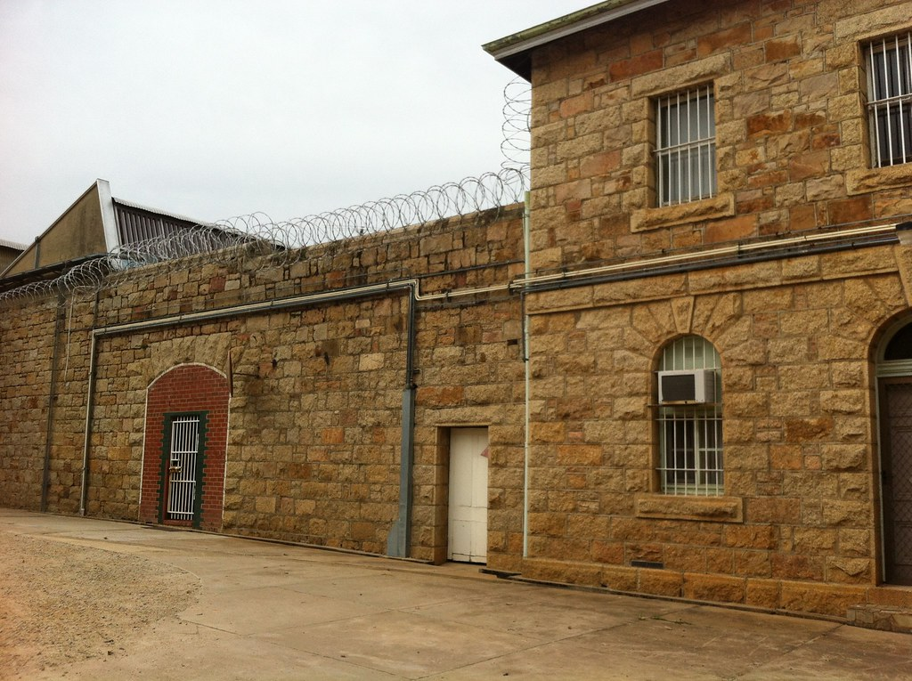

## Read a csv file and convert to a tsibble

```r
prison <- readr::read_csv("data/prison_population.csv")
#readr::read_csv("~/STA364/data/prison_population.csv")
```

```
# A tibble: 3,072 × 6
   date       state gender legal     indigenous count
   <date>     <chr> <chr>  <chr>     <chr>      <dbl>
 1 2005-03-01 ACT   Female Remanded  ATSI           0
 2 2005-03-01 ACT   Female Remanded  Other          2
 3 2005-03-01 ACT   Female Sentenced ATSI           0
 4 2005-03-01 ACT   Female Sentenced Other          0
 5 2005-03-01 ACT   Male   Remanded  ATSI           7
 6 2005-03-01 ACT   Male   Remanded  Other         58
 7 2005-03-01 ACT   Male   Sentenced ATSI           0
 8 2005-03-01 ACT   Male   Sentenced Other          0
 9 2005-03-01 NSW   Female Remanded  ATSI          51
10 2005-03-01 NSW   Female Remanded  Other        131
# ℹ 3,062 more rows
```

## Read a csv file and convert to a tsibble

```r
prison <- readr::read_csv("data/prison_population.csv") |>
  mutate(Quarter = yearquarter(date))
```

```
# A tibble: 3,072 × 7
   date       state gender legal     indigenous count Quarter
   <date>     <chr> <chr>  <chr>     <chr>      <dbl>   <qtr>
 1 2005-03-01 ACT   Female Remanded  ATSI           0 2005 Q1
 2 2005-03-01 ACT   Female Remanded  Other          2 2005 Q1
 3 2005-03-01 ACT   Female Sentenced ATSI           0 2005 Q1
 4 2005-03-01 ACT   Female Sentenced Other          0 2005 Q1
 5 2005-03-01 ACT   Male   Remanded  ATSI           7 2005 Q1
 6 2005-03-01 ACT   Male   Remanded  Other         58 2005 Q1
 7 2005-03-01 ACT   Male   Sentenced ATSI           0 2005 Q1
 8 2005-03-01 ACT   Male   Sentenced Other          0 2005 Q1
 9 2005-03-01 NSW   Female Remanded  ATSI          51 2005 Q1
10 2005-03-01 NSW   Female Remanded  Other        131 2005 Q1
# ℹ 3,062 more rows
```

## Read a csv file and convert to a tsibble

```r
prison <- readr::read_csv("data/prison_population.csv") |>
  mutate(Quarter = yearquarter(date)) |>
  select(-date)
```

```
# A tibble: 3,072 × 6
   state gender legal     indigenous count Quarter
   <chr> <chr>  <chr>     <chr>      <dbl>   <qtr>
 1 ACT   Female Remanded  ATSI           0 2005 Q1
 2 ACT   Female Remanded  Other          2 2005 Q1
 3 ACT   Female Sentenced ATSI           0 2005 Q1
 4 ACT   Female Sentenced Other          0 2005 Q1
 5 ACT   Male   Remanded  ATSI           7 2005 Q1
 6 ACT   Male   Remanded  Other         58 2005 Q1
 7 ACT   Male   Sentenced ATSI           0 2005 Q1
 8 ACT   Male   Sentenced Other          0 2005 Q1
 9 NSW   Female Remanded  ATSI          51 2005 Q1
10 NSW   Female Remanded  Other        131 2005 Q1
# ℹ 3,062 more rows
```

## Read a csv file and convert to a tsibble

```r
prison <- readr::read_csv("data/prison_population.csv") |>
  mutate(Quarter = yearquarter(date)) |>
  select(-date) |>
  as_tsibble(
    index = Quarter,
    key = c(state, gender, legal, indigenous)
  )
```

```
# A tsibble: 5 x 6 [1Q]
# Key:       state, gender, legal, indigenous [1]
  state gender legal    indigenous count Quarter
  <chr> <chr>  <chr>    <chr>      <dbl>   <qtr>
1 ACT   Female Remanded ATSI           0 2005 Q1
2 ACT   Female Remanded ATSI           1 2005 Q2
3 ACT   Female Remanded ATSI           0 2005 Q3
4 ACT   Female Remanded ATSI           0 2005 Q4
5 ACT   Female Remanded ATSI           1 2006 Q1
```

# Example: Australian pharmaceutical sales

## Australian Pharmaceutical Benefits Scheme

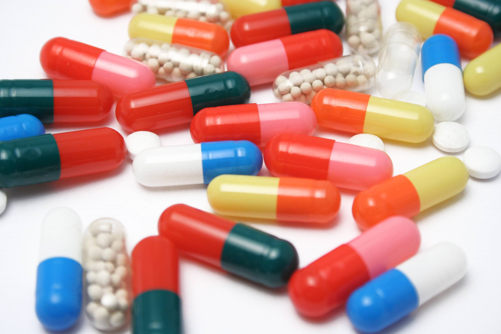

## Australian Pharmaceutical Benefits Scheme

The *Pharmaceutical Benefits Scheme* (PBS) is the Australian government drugs subsidy scheme.

- Many drugs bought from pharmacies are subsidised to allow more equitable access to modern drugs.
- The cost to government is determined by the number and types of drugs purchased. Currently nearly 1% of GDP.
- The total cost is budgeted based on forecasts of drug usage.
- Costs are disaggregated by drug type (ATC1 x15 / ATC2 84), concession category (x2) and patient type (x2), giving $84\times2\times2=336$ time series.

## Working with `tsibble` objects

```r
PBS |> head(5)
```

```
# A tsibble: 5 x 9 [1M]
# Key:       Concession, Type, ATC1, ATC2 [1]
     Month Concession   Type        ATC1  ATC1_desc          ATC2  ATC2_desc Scripts  Cost
     <mth> <chr>        <chr>       <chr> <chr>              <chr> <chr>       <dbl> <dbl>
1 1991 Jul Concessional Co-payments A     Alimentary tract … A01   STOMATOL…   18228 67877
2 1991 Aug Concessional Co-payments A     Alimentary tract … A01   STOMATOL…   15327 57011
3 1991 Sep Concessional Co-payments A     Alimentary tract … A01   STOMATOL…   14775 55020
4 1991 Oct Concessional Co-payments A     Alimentary tract … A01   STOMATOL…   15380 57222
5 1991 Nov Concessional Co-payments A     Alimentary tract … A01   STOMATOL…   14371 52120
```

## Working with `tsibble` objects

We can use the `filter()` function to select rows.

```r
PBS |>
  filter(ATC2 == "A10")|>
  head(5)
```

```
# A tsibble: 5 x 9 [1M]
# Key:       Concession, Type, ATC1, ATC2 [1]
     Month Concession   Type        ATC1  ATC1_desc         ATC2  ATC2_desc Scripts   Cost
     <mth> <chr>        <chr>       <chr> <chr>             <chr> <chr>       <dbl>  <dbl>
1 1991 Jul Concessional Co-payments A     Alimentary tract… A10   ANTIDIAB…   89733 2.09e6
2 1991 Aug Concessional Co-payments A     Alimentary tract… A10   ANTIDIAB…   77101 1.80e6
3 1991 Sep Concessional Co-payments A     Alimentary tract… A10   ANTIDIAB…   76255 1.78e6
4 1991 Oct Concessional Co-payments A     Alimentary tract… A10   ANTIDIAB…   78681 1.85e6
5 1991 Nov Concessional Co-payments A     Alimentary tract… A10   ANTIDIAB…   70554 1.69e6
```

## Working with `tsibble` objects

We can use the `select()` function to select columns.

```r
PBS |>
  filter(ATC2 == "A10") |>
  select(Month, Concession, Type, Cost)|>
  head(5)
```

```
# A tsibble: 5 x 4 [1M]
# Key:       Concession, Type [1]
     Month Concession   Type           Cost
     <mth> <chr>        <chr>         <dbl>
1 1991 Jul Concessional Co-payments 2092878
2 1991 Aug Concessional Co-payments 1795733
3 1991 Sep Concessional Co-payments 1777231
4 1991 Oct Concessional Co-payments 1848507
5 1991 Nov Concessional Co-payments 1686458
```

## Working with `tsibble` objects

We can use the `summarise()` function to summarise over keys.

```r
PBS |>
  filter(ATC2 == "A10") |>
  select(Month, Concession, Type, Cost) |>
  summarise(total_cost = sum(Cost))|>
  head(5)
```

```
# A tsibble: 5 x 2 [1M]
     Month total_cost
     <mth>      <dbl>
1 1991 Jul    3526591
2 1991 Aug    3180891
3 1991 Sep    3252221
4 1991 Oct    3611003
5 1991 Nov    3565869
```

## Working with `tsibble` objects

We can use the `mutate()` function to create new variables.

```r
PBS |>
  filter(ATC2 == "A10") |>
  select(Month, Concession, Type, Cost) |>
  summarise(total_cost = sum(Cost)) |>
  mutate(total_cost = total_cost / 1e6)|>
  head(5)
```

```
# A tsibble: 5 x 2 [1M]
     Month total_cost
     <mth>      <dbl>
1 1991 Jul       3.53
2 1991 Aug       3.18
3 1991 Sep       3.25
4 1991 Oct       3.61
5 1991 Nov       3.57
```

## Working with `tsibble` objects

We can use the `mutate()` function to create new variables.

```r
a10 <- PBS |>
  filter(ATC2 == "A10") |>
  select(Month, Concession, Type, Cost) |>
  summarise(total_cost = sum(Cost)) |>
  mutate(total_cost = total_cost / 1e6) |>
  head(5)
```

```
# A tsibble: 5 x 2 [1M]
     Month total_cost
     <mth>      <dbl>
1 1991 Jul       3.53
2 1991 Aug       3.18
3 1991 Sep       3.25
4 1991 Oct       3.61
5 1991 Nov       3.57
```

# Time plots

## Time plots

```r
a10 |>
  autoplot(total_cost)
```

[figure not shown]

## Ansett airlines

```r
ansett |>
  autoplot(Passengers)
```

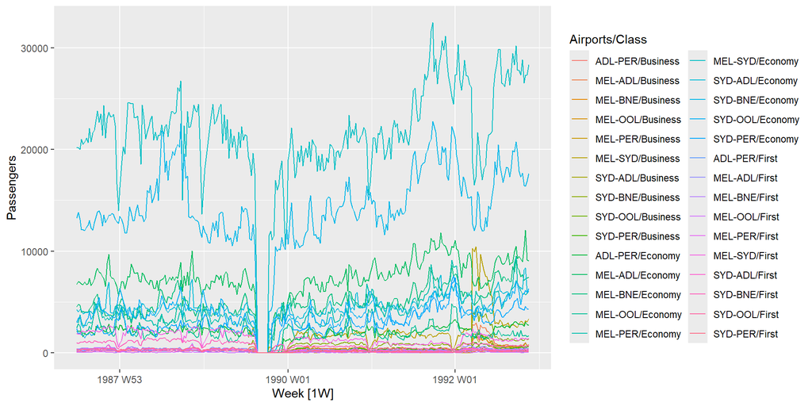

## Ansett airlines

```r
ansett |>
  filter(Class == "Economy") |>
  autoplot(Passengers)
```

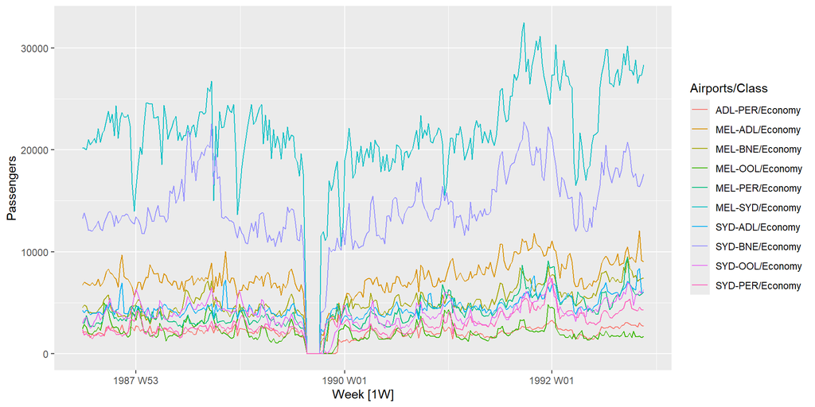

## Ansett airlines

```r
ansett |>
  filter(Airports == "MEL-SYD") |>
  autoplot(Passengers)
```

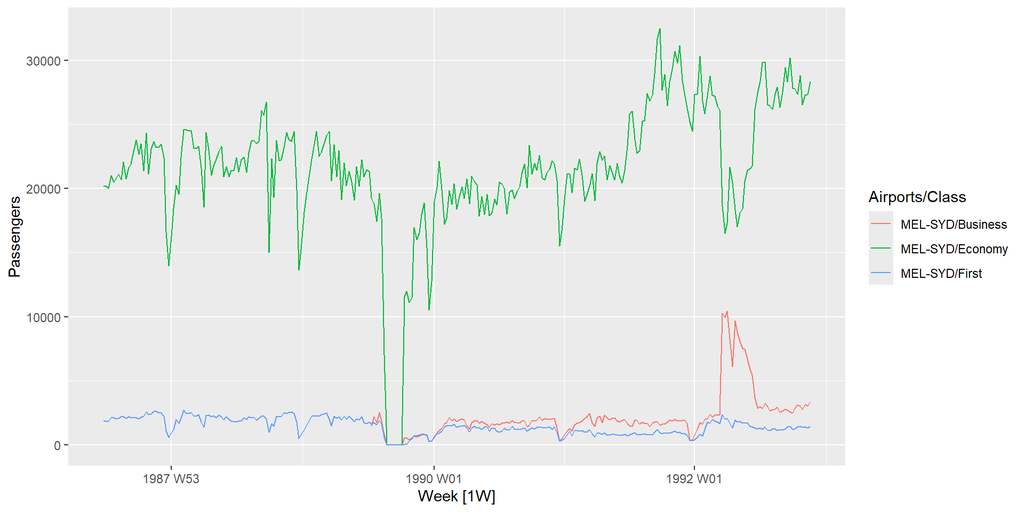

## Time series patterns

**Trend**

pattern exists when there is a long-term increase or decrease in the data.

**Seasonal**

pattern exists when a series is influenced by seasonal factors (e.g., the quarter of the year, the month, or day of the week).

## Time series components

### Differences between seasonal and cyclic patterns:

- seasonal pattern constant length; cyclic pattern variable length
- average length of cycle longer than length of seasonal pattern
- magnitude of cycle more variable than magnitude of seasonal pattern

## Time series patterns

```r
aus_production |>
  filter(year(Quarter) >= 1980) |>
  autoplot(Electricity) +
  labs(y = "GWh", title = "Australian electricity production")
```

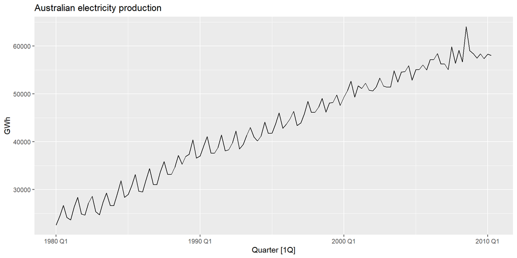

## Time series patterns

```r
aus_production |>
  autoplot(Bricks) +
  labs(y = "million units", title = "Australian clay brick production")
```

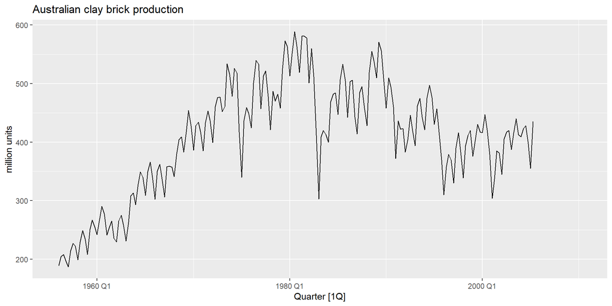

## Time series patterns

```r
us_employment |>
  filter(Title == "Retail Trade", year(Month) >= 1980) |>
  autoplot(Employed / 1e3) +
  labs(y = "Million people", title = "Retail employment, USA")
```

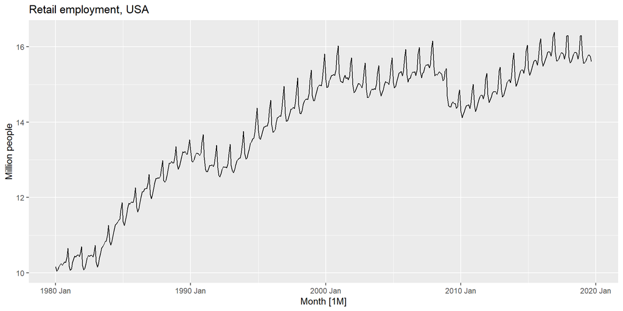

## Time series patterns

```r
gafa_stock |>
  filter(Symbol == "AMZN", year(Date) >= 2018) |>
  autoplot(Close) +
  labs(y = "$US", title = "Amazon closing stock price")
```

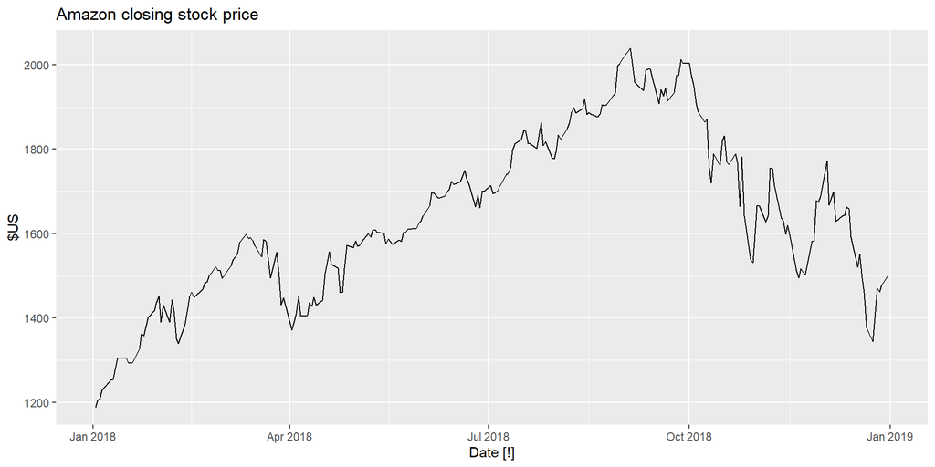

## Time series patterns

```r
pelt |>
  autoplot(Lynx) +
  labs(y="Number trapped", title = "Annual Canadian Lynx Trappings")
```

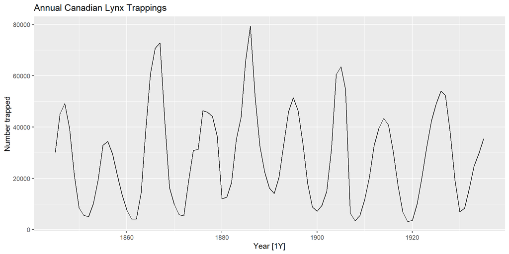

## Seasonal or cyclic?

- seasonal pattern constant length; cyclic pattern variable length
- average length of cycle longer than length of seasonal pattern
- magnitude of cycle more variable than magnitude of seasonal pattern

# Seasonal and subseries plots

## Seasonal plots

```r
a10 |> gg_season(total_cost, labels = "both") +
  labs(y = "$ million", title = "Seasonal plot: antidiabetic drug sales")
```

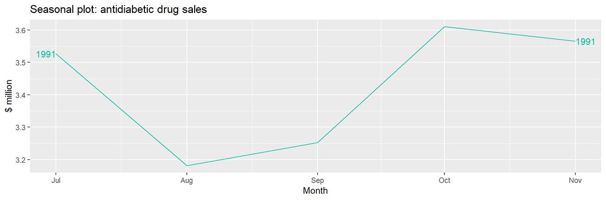

## Seasonal plots

- Data plotted against the individual “seasons” in which the data were observed. (In this case a “season” is a month.)
- Something like a time plot except that the data from each season are overlapped.
- Enables the underlying seasonal pattern to be seen more clearly, and also allows any substantial departures from the seasonal pattern to be easily identified.
- In R: `gg_season()`

## Seasonal subseries plots

```r
a10 |>
  gg_subseries(total_cost) +
  labs(y = "$ million", title = "Subseries plot: antidiabetic drug sales")
```

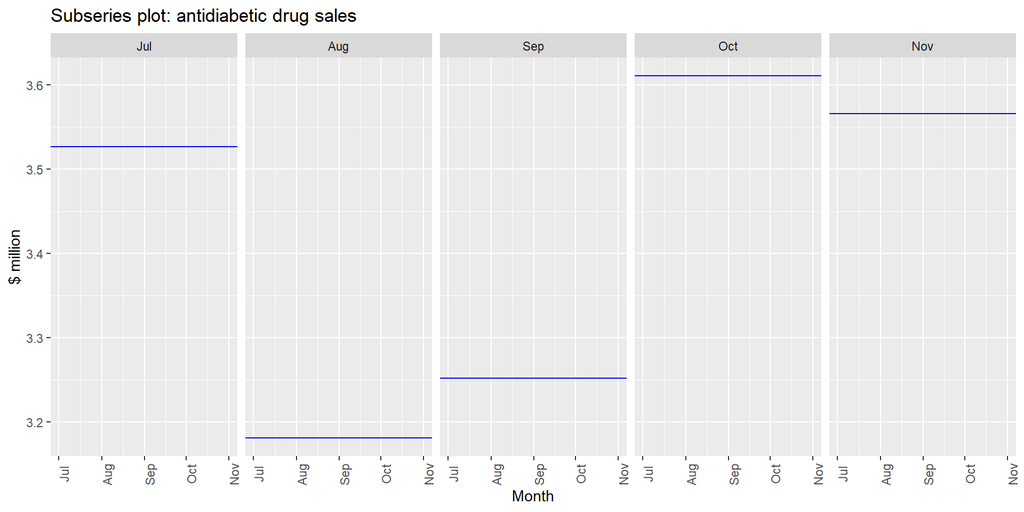

## Seasonal subseries plots

- Data for each season collected together in time plot as separate time series.
- Enables the underlying seasonal pattern to be seen clearly, and changes in seasonality over time to be visualized.
- In R: `gg_subseries()`

## Quarterly Australian Beer Production

```r
beer <- aus_production |>
  select(Quarter, Beer) |>
  filter(year(Quarter) >= 1992)
beer |> autoplot(Beer)
```

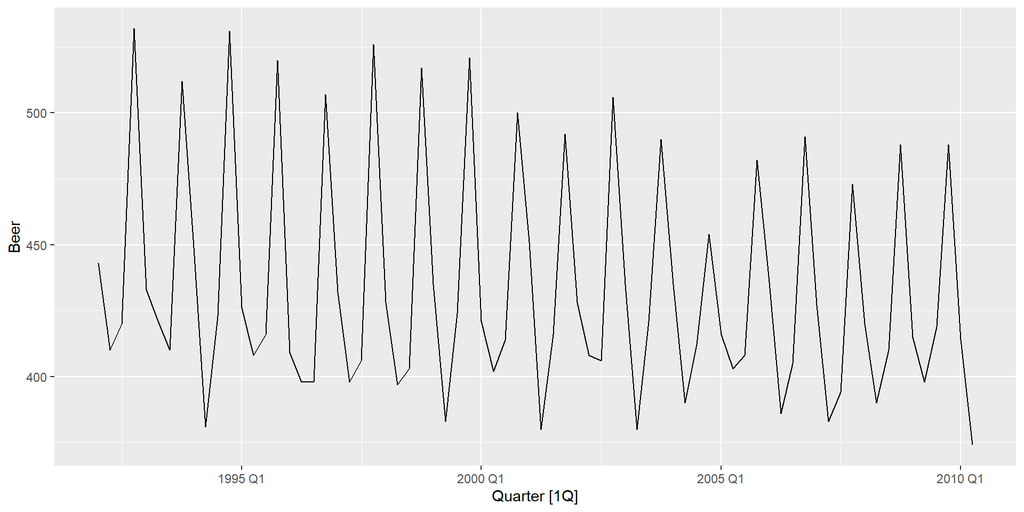

## Quarterly Australian Beer Production

```r
beer |> gg_season(Beer, labels="right")
```

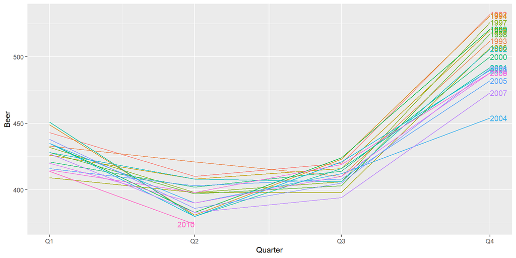

## Quarterly Australian Beer Production

```r
beer |> gg_subseries(Beer)
```

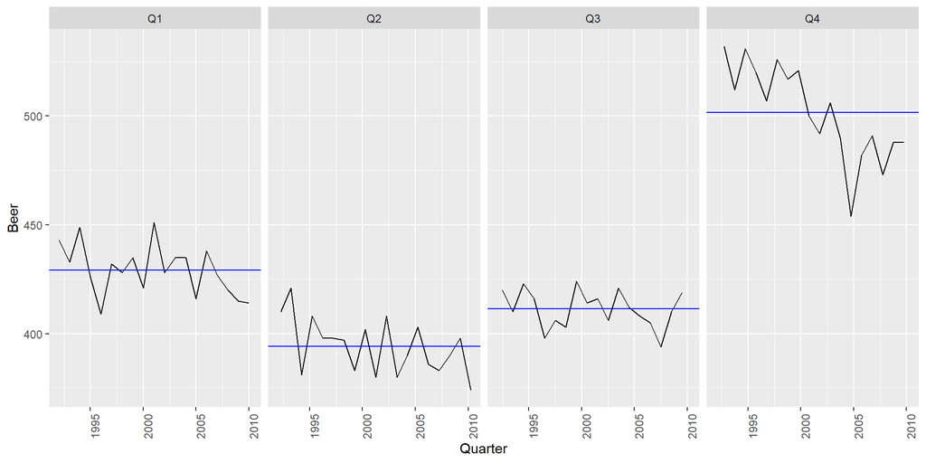

## Multiple seasonal periods

```r
vic_elec
```

```
# A tsibble: 52,608 x 5 [30m] <Australia/Melbourne>
   Time                Demand Temperature Date       Holiday
   <dttm>               <dbl>       <dbl> <date>     <lgl>
 1 2012-01-01 00:00:00  4383.        21.4 2012-01-01 TRUE
 2 2012-01-01 00:30:00  4263.        21.0 2012-01-01 TRUE
 3 2012-01-01 01:00:00  4049.        20.7 2012-01-01 TRUE
 4 2012-01-01 01:30:00  3878.        20.6 2012-01-01 TRUE
 5 2012-01-01 02:00:00  4036.        20.4 2012-01-01 TRUE
 6 2012-01-01 02:30:00  3866.        20.2 2012-01-01 TRUE
 7 2012-01-01 03:00:00  3694.        20.1 2012-01-01 TRUE
 8 2012-01-01 03:30:00  3562.        19.6 2012-01-01 TRUE
 9 2012-01-01 04:00:00  3433.        19.1 2012-01-01 TRUE
10 2012-01-01 04:30:00  3359.        19.0 2012-01-01 TRUE
# ℹ 52,598 more rows
```

## Multiple seasonal periods

```r
vic_elec |> gg_season(Demand)
```

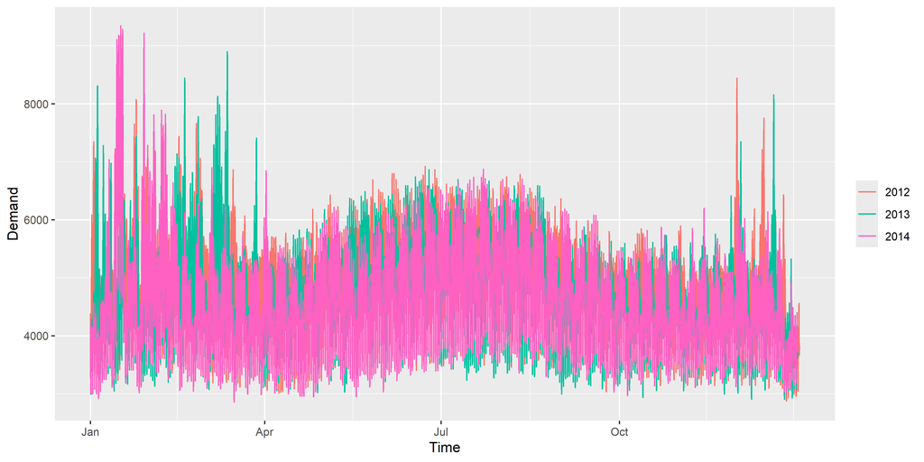

## Multiple seasonal periods

```r
vic_elec |> gg_season(Demand, period = "week")
```

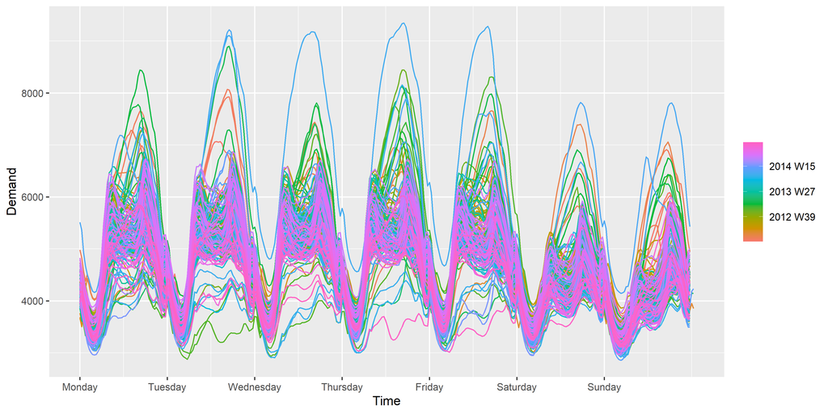

## Multiple seasonal periods

```r
vic_elec |> gg_season(Demand, period = "day")
```

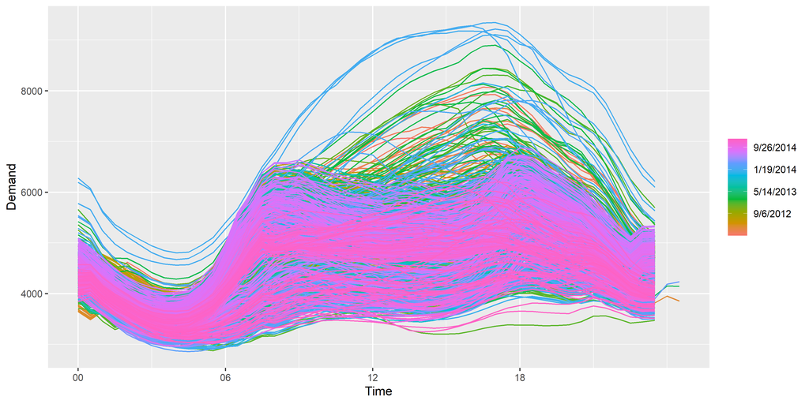

## Australian holidays

```r
holidays <- tourism |>
  filter(Purpose == "Holiday") |>
  group_by(State) |>
  summarise(Trips = sum(Trips))
```

```
# A tsibble: 640 x 3 [1Q]
# Key:       State [8]
   State Quarter Trips
   <chr>   <qtr> <dbl>
 1 ACT   1998 Q1  196.
 2 ACT   1998 Q2  127.
 3 ACT   1998 Q3  111.
 4 ACT   1998 Q4  170.
 5 ACT   1999 Q1  108.
 6 ACT   1999 Q2  125.
 7 ACT   1999 Q3  178.
 8 ACT   1999 Q4  218.
 9 ACT   2000 Q1  158.
10 ACT   2000 Q2  155.
# ℹ 630 more rows
```

## Australian holidays

```r
holidays |> autoplot(Trips) +
  labs(y = "thousands of trips", title = "Australian domestic holiday nights")
```

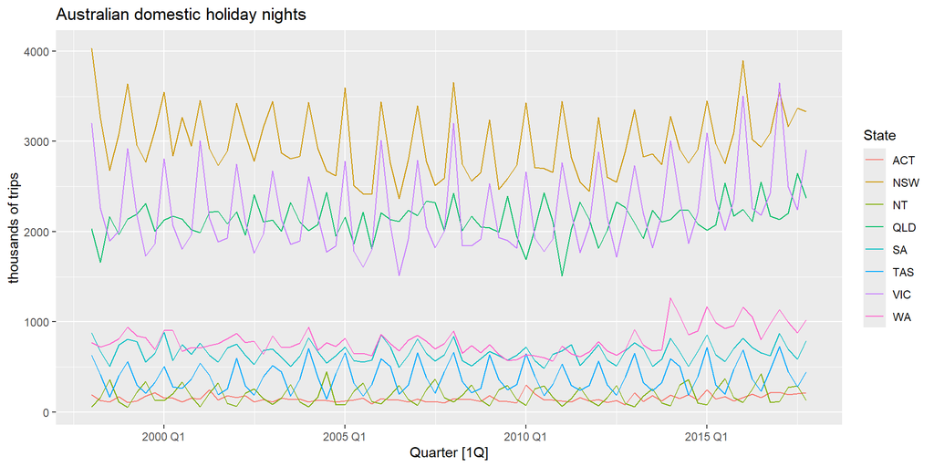

## Seasonal plots

```r
holidays |> gg_season(Trips) +
  labs(y = "thousands of trips", title = "Australian domestic holiday nights")
```

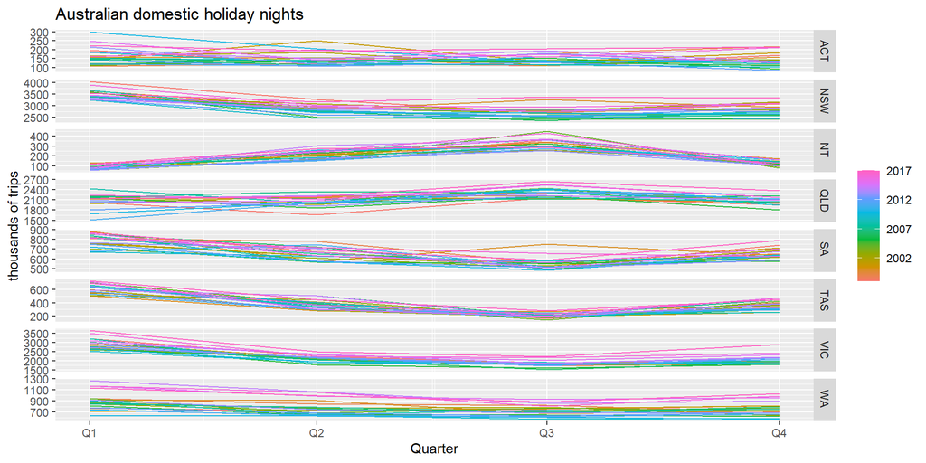

## Seasonal subseries plots

```r
holidays |>
  gg_subseries(Trips) +
  labs(y = "thousands of trips", title = "Australian domestic holiday nights")
```

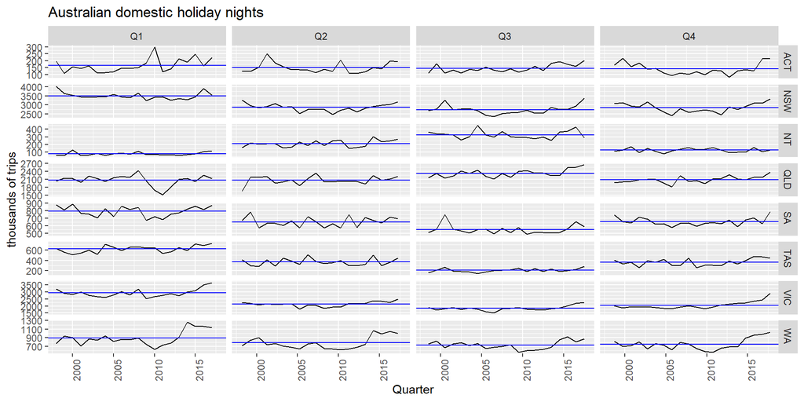

# Lag plots and autocorrelation

## Example: Beer production

```r
new_production <- aus_production |>
  filter(year(Quarter) >= 1992)
new_production
```

```
# A tsibble: 74 x 7 [1Q]
   Quarter  Beer Tobacco Bricks Cement Electricity   Gas
     <qtr> <dbl>   <dbl>  <dbl>  <dbl>       <dbl> <dbl>
 1 1992 Q1   443    5777    383   1289       38332   117
 2 1992 Q2   410    5853    404   1501       39774   151
 3 1992 Q3   420    6416    446   1539       42246   175
 4 1992 Q4   532    5825    420   1568       38498   129
 5 1993 Q1   433    5724    394   1450       39460   116
 6 1993 Q2   421    6036    462   1668       41356   149
 7 1993 Q3   410    6570    475   1648       42949   163
 8 1993 Q4   512    5675    443   1863       40974   138
 9 1994 Q1   449    5311    421   1468       40162   127
10 1994 Q2   381    5717    475   1755       41199   159
# ℹ 64 more rows
```

## Example: Beer production

```r
new_production |> gg_lag(Beer)
```

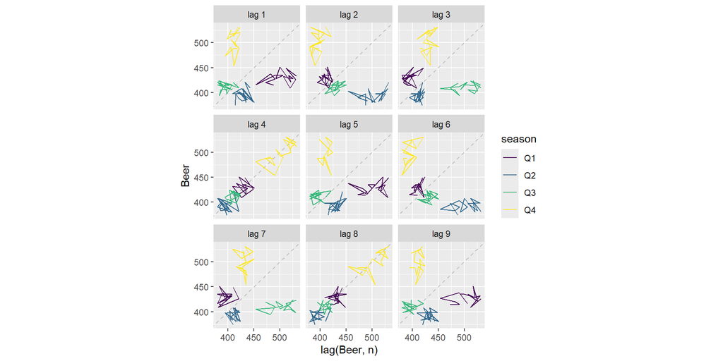

## Example: Beer production

```r
new_production |> gg_lag(Beer, geom='point')
```

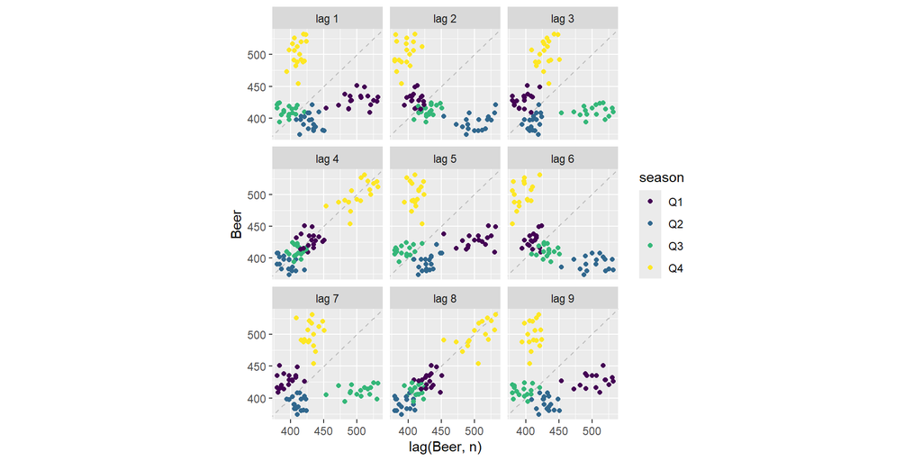

## Lagged scatterplots

- Each graph shows $y_t$ plotted against $y_{t-k}$ for different values of $k$.
- The autocorrelations are the correlations associated with these scatterplots.
- ACF (autocorrelation function):
  - $r_1=\text{Correlation}(y_{t}, y_{t-1})$
  - $r_2=\text{Correlation}(y_{t}, y_{t-2})$
  - $r_3=\text{Correlation}(y_{t}, y_{t-3})$
  - etc.

## Autocorrelation

**Covariance** and **correlation**: measure extent of **linear relationship** between two variables ($y$ and $X$).

**Autocovariance** and **autocorrelation**: measure linear relationship between **lagged values** of a time series $y$.

We measure the relationship between:

- $y_{t}$ and $y_{t-1}$
- $y_{t}$ and $y_{t-2}$
- $y_{t}$ and $y_{t-3}$
- etc.

## Autocorrelation

Results for first 9 lags for beer data:

```r
new_production |> ACF(Beer, lag_max = 9)
```

```
# A tsibble: 9 x 2 [1Q]
       lag     acf
  <cf_lag>   <dbl>
1       1Q -0.102
2       2Q -0.657
3       3Q -0.0603
4       4Q  0.869
5       5Q -0.0892
6       6Q -0.635
7       7Q -0.0542
8       8Q  0.832
9       9Q -0.108
```

## Autocorrelation

Results for first 9 lags for beer data:

```r
new_production |> ACF(Beer, lag_max = 9) |> autoplot()
```

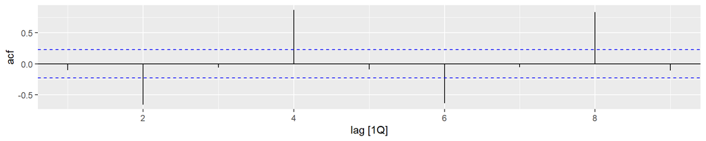

## Autocorrelation

```r
new_production |> ACF(Beer) |> autoplot()
```

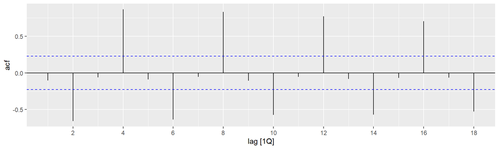

## Trend and seasonality in ACF plots

- When data have a trend, the autocorrelations for small lags tend to be large and positive.
- When data are seasonal, the autocorrelations will be larger at the seasonal lags (i.e., at multiples of the seasonal frequency)
- When data are trended and seasonal, you see a combination of these effects.

## Autocorrelation functions

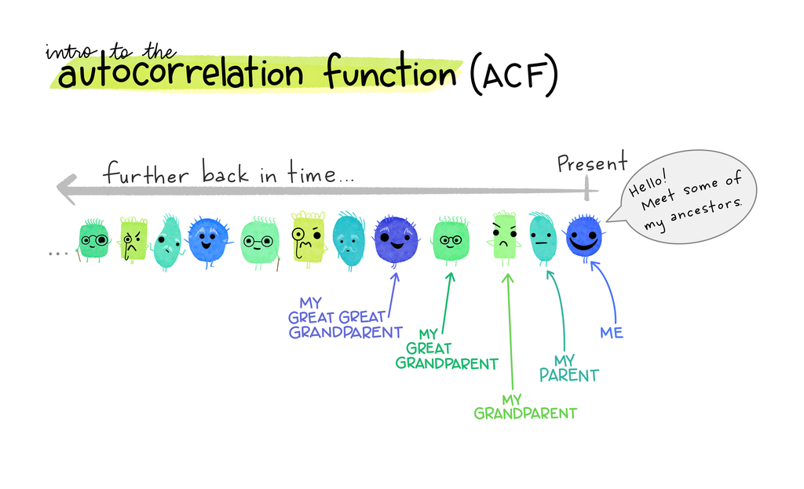

Artwork by @allison_horst

## US retail trade employment

```r
retail <- us_employment |>
  filter(Title == "Retail Trade", year(Month) >= 1980)
retail |> autoplot(Employed)
```

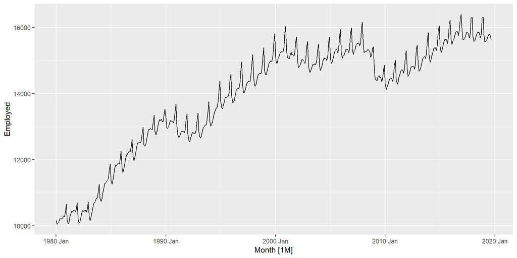

## US retail trade employment

```r
retail |>
  ACF(Employed, lag_max = 48) |>
  autoplot()
```

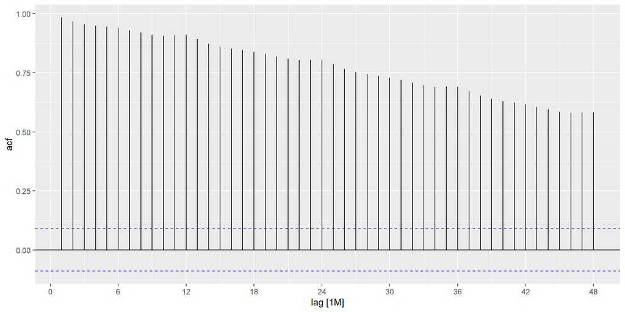

## Google stock price

```r
google_2015 <- gafa_stock |>
  filter(Symbol == "GOOG", year(Date) == 2015) |>
  select(Date, Close)
google_2015
```

```
# A tsibble: 252 x 2 [!]
   Date       Close
   <date>     <dbl>
 1 2015-01-02  522.
 2 2015-01-05  511.
 3 2015-01-06  499.
 4 2015-01-07  498.
 5 2015-01-08  500.
 6 2015-01-09  493.
 7 2015-01-12  490.
 8 2015-01-13  493.
 9 2015-01-14  498.
10 2015-01-15  499.
# ℹ 242 more rows
```

## Google stock price

```r
google_2015 |> autoplot(Close)
```

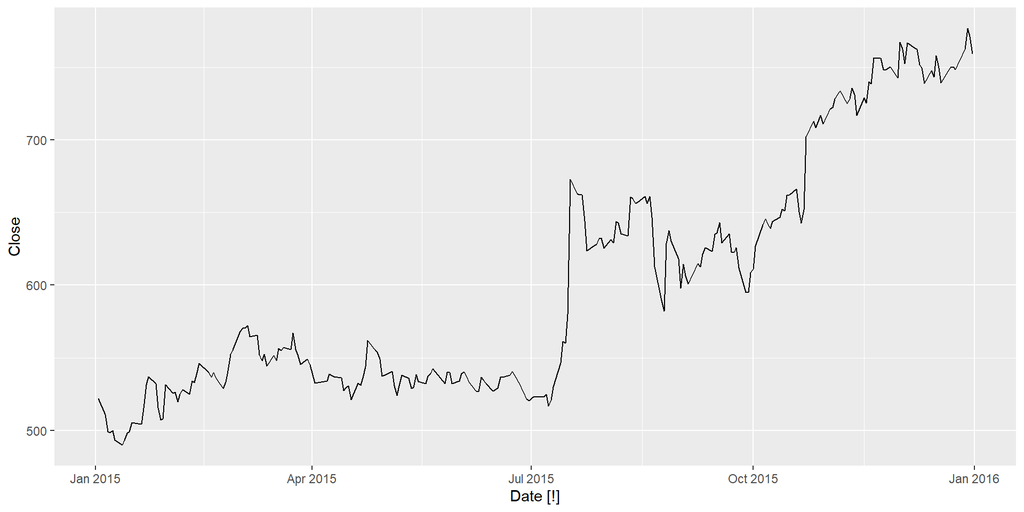